# Communicate Data Findings: Ford Go-Bike Project

## Hunter Sparrow: Data Analysis Udacity Nanodegree

## Investigation Overview

> Ford GoBike is expanding the area’s existing bike-share program to 546 stations and 7,000 bikes serving San Francisco, San Jose and East Bay; riders can access GoBike through the FordPass. Fastest-growing mode of transportation with usage surging 184 percent between 2006 and 2015, according to the San Francisco Municipal Transportation Agency.
> - What time do people most use this service?
> - What day of the week is most busy, least busy? (By user_type)
> - What time of the day is the most demanding?
> - Who uses this service the most? (subscribers / customers)
> - Who uses this service the most by age and gender?
> - How long to people normally use this bike?

## Dataset Overview

> The data consists of information regarding 183,000 rides made in a bike-sharing system covering the greater San Francisco Bay area. The data features include duration (secs) and others such as DateTime, customer type, gender, as well as some additional variables. Data can be downloaded here: https://video.udacity-data.com/topher/2020/October/5f91cf38_201902-fordgobike-tripdata/201902-fordgobike-tripdata.csv

## Age Distribution of Riders

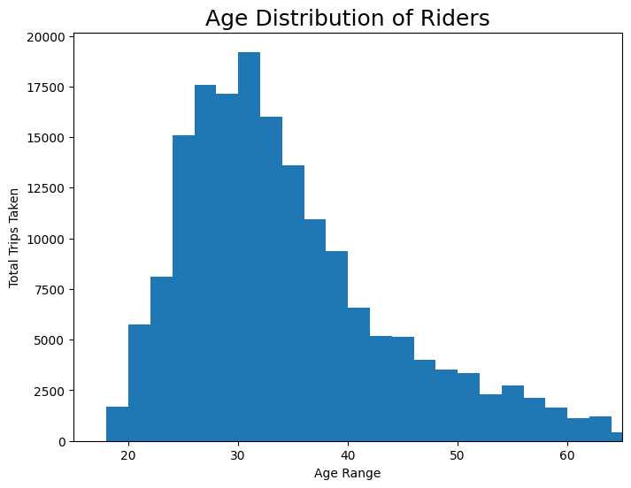

A histogram was used to show the distribution of riders by age. Age 25-35, has the highest count. Whereas, ages 45-65 being on the lower end of the age distribution.

## Ratio of Trips by Gender

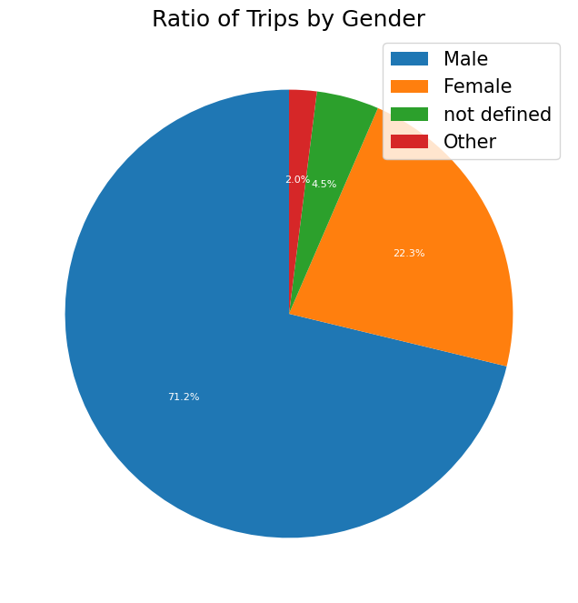

A pie chart was used to show the ratio of genders. 71.2% are makes and 22.3% are females. Other 6.5% percent was not defined or other.

## Peak Rental Hours

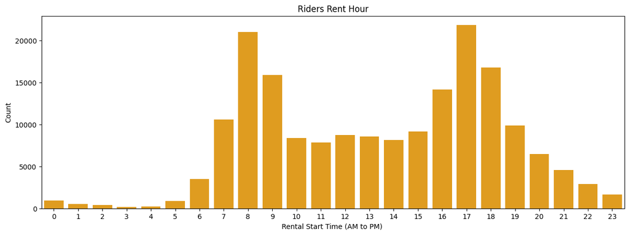

## Trip Duration by Age

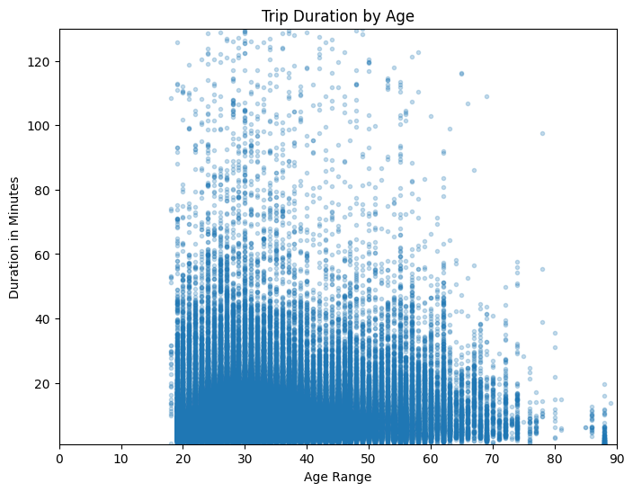

Ages 28- 33 use the service for the longest.

## Average Trip by User

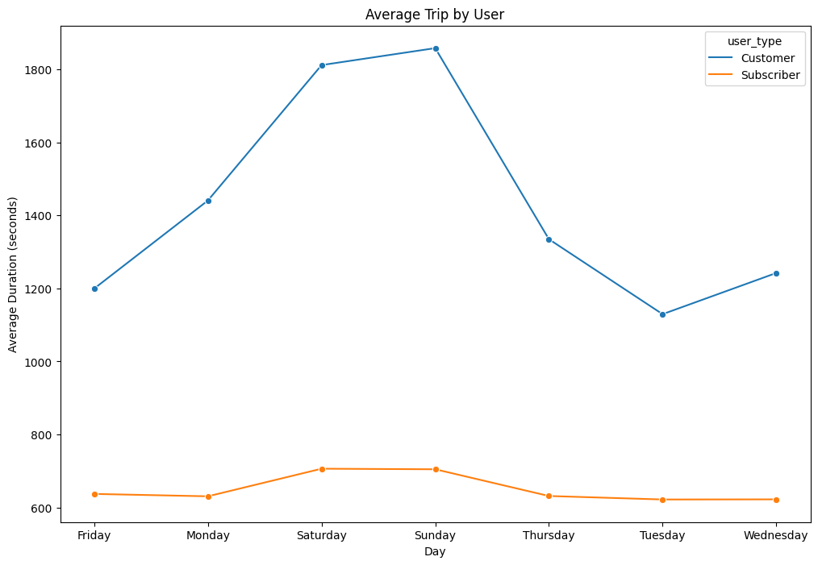

A line plot was used to show the average duration customers versus subscribers used the bike service. Customers use the bike serive more than cusotmers especially on Saturdays and Sundays.

## Subscriber weekly rental activity for February

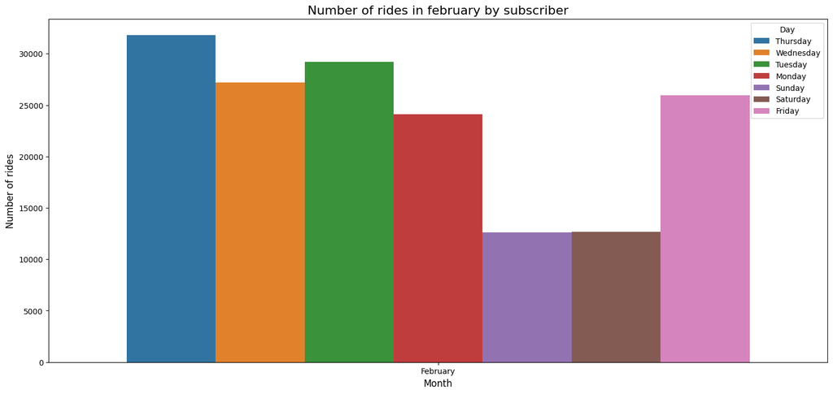